# **【Daily Living Water】**

2022 May

# **May 13**, Matthew 4:23~25

- [Reading together](https://www.youtube.com/watch?v=X9PdL9EYerU)
- 【Teaching and Healing】

[figure not shown]

[image from](https://www.fggam.org/2014/05/ministry-jesus-christ/)

# **May 14**, Matthew 5:1~12

- [Reading together](https://www.youtube.com/watch?v=2OCs6ve-HsU)
- 【You’re Blessed】

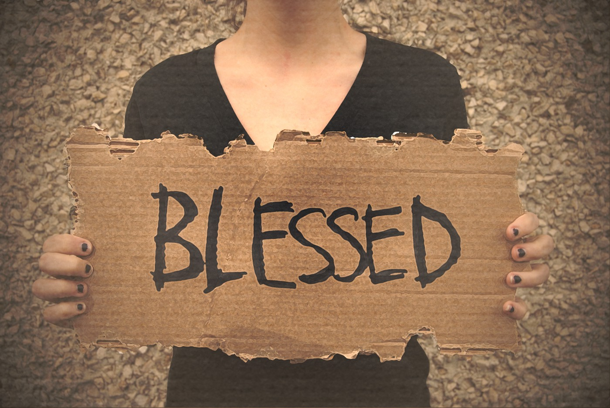

[image from](https://medium.com/josh-bocanegra/i-used-to-say-i-m-blessed-until-i-asked-these-2-questions-d775456dd813)

**When Jesus saw his ministry drawing huge crowds, he climbed a hillside. Those who were apprenticed to him, the committed, he sat down and taught his climbing companions. This is what he said:**

**“You’re blessed when you’re at the end of your rope. With less of you there is more of God and his rules. ”You’re blessed when you feel you’ve lost what is most dear to you. Only then can you be embraced by the One most dear to you.** **“You’re blessed when you’re content with just who you are–no more, no less. That’s the moment you find yourselves proud owners of everything that can’t be bought. ”You’re blessed when you’ve worked up a good appetite for God. He’s food and drink in the best meal you’ll ever eat.** **“You’re blessed when you care. At the moment of being ‘care-full’, you find yourselves cared for. ”You’re blessed when you get your inside world–your mind and heart–put right. Then you can see God in the outside world.** **“You’re blessed when you can show people how to cooperate instead of compete or fight. That’s when you discover who you really are, and your place in God’s family. ”You’re blessed when your commitment to God provokes persecution. The persecution drives you even deeper into God’s kingdom.**

**“Not only that–count yourselves blessed every time people put you down or throw you out or speak lies about you to discredit me. What it means is that the truth is too close for comfort and they are uncomfortable. You can be glad when that happens–give a cheer,even!–for though they don’t like it, I do! And all heaven applauds. And know that you are in good company. My prophets and witnesses have always gotten into this kind of trouble.”**

# **May 15**

- Sunday

# **May 16**, Matthew 5:13~16

- [Reading together](https://www.youtube.com/watch?v=zNDJ6fA5yz4)
- 【Salt and light】

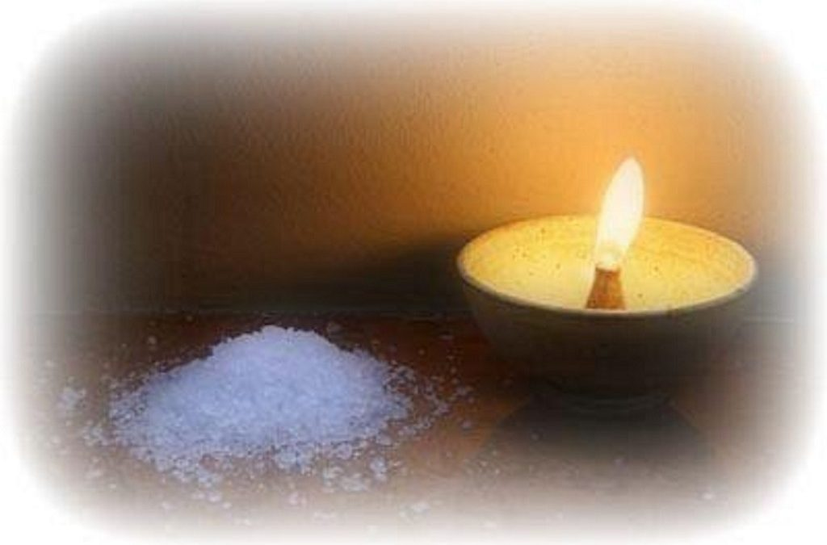

[image from](https://www.suoredimariabambina.org/en/every-day-holiness-is-being-salt-and-light-for-others/)

**"Let me tell you why you are here. You’re here to be salt-seasoning that brings out the God-flavors of this earth. If you lose your saltiness, how will people taste godliness? You’ve lost your usefulness and will end up in the garbage.**

**"Here’s another way to put it: You’re here to be light, bringing out the God-colors in the world. God is not a secret to be kept. We’re going public with this, as public as a city on a hill. If I make you light-bearers, you don’t think I’m going to hide you under a bucket, do you? I’m putting you on a light stand. Now that I’ve put you on the hilltop, on a light stand–shine! Keep open house, be generous with your lives. By opening up to others, you’ll prompt people to open up with God, this generous Father in heaven.**

# **May 17**, Matthew 5:17~20

- [Reading together](https://www.youtube.com/watch?v=oytROS6xue8&ab_channel=%E5%8F%B0%E4%B8%AD%E5%BF%A0%E5%AD%9D%E8%B7%AF%E9%95%B7%E8%80%81%E6%95%99%E6%9C%83)
- 【Completing God’s Law】

[figure not shown]

[image from](https://alabastergraceministries.org/alabaster-grace-notes/blog/god-s-law-is-perfect-f33eba12-c28e-44df-99fd-ca86327b149c)

**"Don’t suppose for a minute that I have come to demolish the Scriptures–either God’s Law or Prophets. I’m not here to demolish but to complete. I am going to put it all together, pull it all together in a vast panorama. God’s Law is more real and lasting than the stars in the sky and the ground at your feet. Long after the stars burn out and earth wears out, God’s Law will be alive and working.**

**"Trivialize even the smallest item in God’s Law and you will only have trivialized yourself. But take it seriously, show the way for others, and you will find the honor in the kingdom. Unless you do far better than the Pharisees in the matters of right living, you won’t know the first thing about entering the kingdom.**

# **May 18**, Matthew 5:21~26

- [Reading together](https://www.youtube.com/watch?v=f29967qzkCM)
- 【Murder】

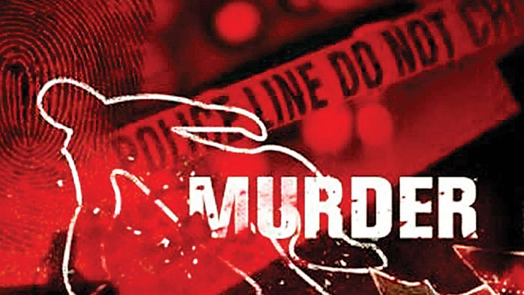

[image from](https://blog.ipleaders.in/murder-under-indian-penal-code-all-you-need-to-know-about-it/)

**"You’re familiar with the command to the ancients, ‘Do not murder.’ I’m telling you that anyone who is so much as angry with a brother or sister is guilty of murder. Carelessly call a brother ‘idiot!’ and you just might find yourself hauled into court. Thoughtlessly yell ‘stupid!’ at a sister and you are on a brink of hellfire. The simple moral fact is that words kill.**

**"This is why I want you to conduct yourself in these matters. If you enter your place of worship and, about to make an offering, you suddenly remember a grudge as friend has against you, abandon your offering, leave immediately, go to this friend and make things right. Then and only then, come back and work things out with God.**

**"Or say you’re out on the street and an old enemy accosts you. Don’t lose a minute. Make the first move; make things right with him. After all, if you leave the first move to him, knowing his track record, you’re likely to end up in court, maybe even jail. If that happens, you won’t get out without a stiff fine.**

# **May 19**, Matthew 5:27~32

- [Reading together](https://www.youtube.com/watch?v=2OVzFCxkCmw&ab_channel=%E5%8F%B0%E4%B8%AD%E5%BF%A0%E5%AD%9D%E8%B7%AF%E9%95%B7%E8%80%81%E6%95%99%E6%9C%83)
- 【Adultery and Divorce】

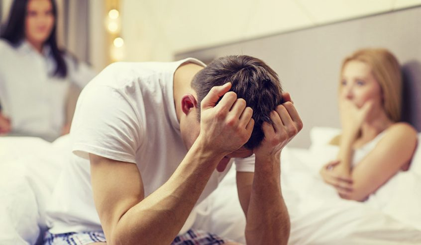

[image from](https://blog.ipleaders.in/adultery-and-divorce/)

**"You know the next commandment pretty well, too: ‘Don’t go to bed with another’s spouse.’ But don’t think you’ve preserved your virtue simply by staying out of bed. Your heart can be corrupted by lust even quicker than your body. Those leering looks you think nobody notices–they also corrupt.**

**"Let’s not pretend this is easier than it really is. If you want to live a morally pure live, here’s what you have to do: You have to blind your right eye the moment you catch it in a lustful leer. You have to choose to live one-eyed or else be dumped on a moral trash pile. And you have to chop off your right hand the moment you notice it raised threateningly. Better a bloody stump than your entire being discarded for good in the dump.**

**"Remember the Scripture that says, ‘Whoever divorces his wife, let him do it legally, giving her divorce papers and her legal rights’? Too many of you are using that as a cover for selfishness and whim, pretending to be righteous just because you are ‘legal’. Please, no more pretending. If you divorce your wife, you’re responsible for making her an adulteress (unless she has already made herself that by sexual promiscuity). And if you marry such a divorced adulteress, you’re automatically an adulterer yourself. You can’t use legal cover to mask a moral failure.**

# **May 20**, Matthew 5:33~37

- [Reading together](https://www.youtube.com/watch?v=8mIZsQaOjgY)
- 【Empty Promises】

# **May 21**, Matthew 5:38~48

- [Reading together](https://www.youtube.com/watch?v=_1SVOtbqm5E)
- 【Love your Enemies】

# **May 22**

- Sunday

# **May 23**, Matthew 6:1~4

- [Reading together](https://www.youtube.com/watch?v=o_P_9eJUjw8)
- 【The World Is Not a Stage】

[figure not shown]

[image from](https://quotefancy.com/quote/1062264/Theodor-W-Adorno-All-the-world-s-not-a-stage)

**"Be especially careful when you are trying to be good so that you don’t make a performance out of it. It might be good theater, but the God who made you won’t be applauding.**

**"When you do something for someone else, don’t call attention to yourself. You’ve seen them in action, I’m sure–‘playactors’ I call them–treating prayer meeting and street corner alike as a stage, acting compassionate as long as someone is watching, playing to the crowds. They get applause, true, but that’s all they get. When you help someone out, don’t think about how it looks. Just do it–quietly and unobtrusively. That is the way your God, who conceived you in love, working behind the scenes, helps you out.**

# **May 24**, Matthew 6:5~15

- [Reading together](https://www.youtube.com/watch?v=_7IxurEwAng)
- 【Pray with Simplicity】

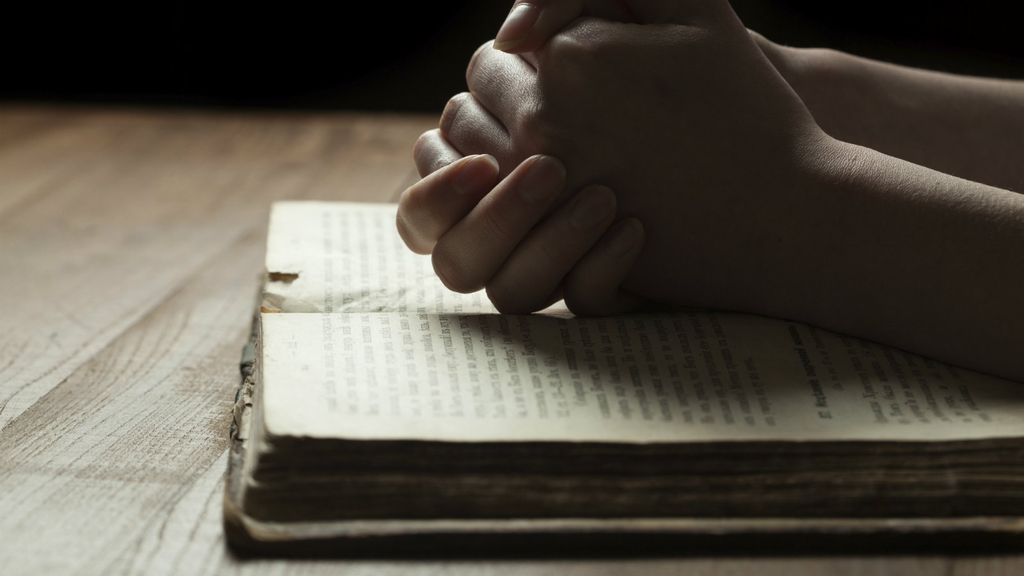

[image from](https://www.desiringgod.org/articles/seven-ways-to-pray-for-your-heart)

**"And when you come before God, don’t turn that into a theatrical production either. All these people making a regular show out of their prayers, hoping for stardom! Do you think God sits in a box seat?**

**"Here’s what I want you to do: Find a quiet, secluded place so you won’t be tempted to role-play before God. Just be there as simply and honestly as you can manage. The focus will shift from you to God, and you will begin to sense his grace.**

**"The world is full of so-called prayer warriors who are prayer-ignorant. They’re full of formulas and programs and advice, peddling techniques for getting what you want from God. Don’t fall for that nonsense. This is your Father you are dealing with, he knows better than you want you need. With a God like this loving you, you can pray very simply. Like this:**

**$\mathcal{Our}\;\mathcal{Father}\;\mathcal{in}\;\mathcal{heaven},\;\mathcal{Reveal}\;\mathcal{who}\;\mathcal{you}\;\mathcal{are}.$**

**$\mathcal{Set}\;\mathcal{the}\;\mathcal{world}\;\mathcal{right};\;\mathcal{Do}\;\mathcal{what's}\;\mathcal{best}--\;\mathcal{as}\;\mathcal{above},\;\mathcal{so}\;\mathcal{below}.$**

**$\mathcal{Keep}\;\mathcal{us}\;\mathcal{alive}\;\mathcal{with}\;\mathcal{three}\;\mathcal{square}\;\mathcal{meals}.$**

**$\mathcal{Keep}\;\mathcal{us}\;\mathcal{forgiven}\;\mathcal{with}\;\mathcal{you}\;\mathcal{and}\;\mathcal{forgiving}\;\mathcal{others}.$**

**$\mathcal{Keep}\;\mathcal{us}\;\mathcal{safe}\;\mathcal{from}\;\mathcal{ourselves}\;\mathcal{and}\;\mathcal{the}\;\mathcal{Devil}.$**

**$\mathcal{You're}\;\mathcal{in}\;\mathcal{charge}!$**

**$\mathcal{You}\;\mathcal{can}\;\mathcal{do}\;\mathcal{anything}\;\mathcal{you}\;\mathcal{want}!$**

**$\mathcal{You're}\;\mathcal{ablaze}\;\mathcal{in}\;\mathcal{beauty}!$**

**$\mathcal{Yes}.\;\mathcal{Yes}.\;\mathcal{Yes}.\;$**

**"In prayer there is a connection between what God does and what you do. You can’t get forgiveness from God, for instance, without also forgiving others. If you refuse to do your part, you cut yourself off from God’s part.**